# Анализ избыточности (Redundancy analysis, RDA)

## Анализ избыточности (Redundancy analysis, RDA)

- Связь нескольких наборов переменных
- Анализ избыточности, теория и практика
- Проверка значимости ординации
- Выбор оптимальной модели
- Частный анализ избыточности и компоненты объясненной инерции
- Компоненты объясненной изменчивости

### Вы сможете

- Проводить анализ избыточности
- Оценивать долю объясненной инерции
- Интерпретировать компоненты по нагрузкам переменных
- Строить ординацию объектов в пространстве компонент
- Проверять значимость модели ординации при помощи пермутационного теста
- Разделять объясненную инерцию на компоненты, связанные с разными наборами переменных, при помощи частного анализа избыточности

## Связь нескольких наборов переменных

## Пример: генетика бабочек Euphydryas editha

Частоты разных аллелей фосфоглюкоизомеразы и данные о факторах среды для 16 колоний бабочек *Euphydryas editha* в Калифорнии и Орегоне

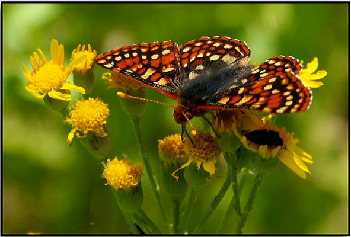

*Euphydryas editha*

Winged Wonder by [Roger Lynn on Flickr](https://flic.kr/p/6CMVsC)

данные McKechnie et al., 1975

## Как вы думаете, что будет определять генетическую структуру в колониях бабочек?

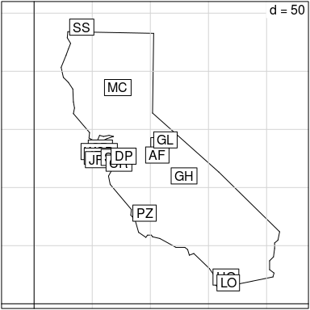

```r
library(ade4)
data(butterfly)
# расположение сайтов
s.label(butterfly$xy, contour = butterfly$contour, inc = FALSE)
```

## Структура данных

- `$xy` - координаты колоний
- `$envir` - 4 фактора среды для колоний
- `$genet` - частоты 6 аллелей в колониях
- `$contour` - карта Калифорнии

```r
str(butterfly, max.level = 2, give.attr = FALSE, vec.len = 2)
```

```
## List of 5
##  $ xy     :'data.frame': 16 obs. of  2 variables:
##   ..$ x: num [1:16] 41 57 56 57 58 ...
##   ..$ y: num [1:16] 238 134 131 127 124 ...
##  $ envir  :'data.frame': 16 obs. of  4 variables:
##   ..$ Altitude     : num [1:16] 500 800 570 550 550 ...
##   ..$ Precipitation: num [1:16] 43 20 28 28 28 ...
##   ..$ Temp_Max     : num [1:16] 98 92 98 98 98 ...
##   ..$ Temp_Min     : num [1:16] 17 32 26 26 26 ...
##  $ genet  :'data.frame': 16 obs. of  6 variables:
##   ..$ 0.4 : num [1:16] 0 0 0 0 0 ...
##   ..$ 0.6 : num [1:16] 3 16 6 4 1 ...
##   ..$ 0.8 : num [1:16] 22 20 28 19 8 ...
##   ..$ 1   : num [1:16] 57 38 46 47 50 ...
##   ..$ 1.16: num [1:16] 17 13 17 27 35 ...
##   ..$ 1.3 : num [1:16] 1 13 3 3 6 ...
##  $ contour:'data.frame': 59 obs. of  4 variables:
##   ..$ x1: num [1:59] 29 103 ...
##   ..$ y1: num [1:59] 234 233 ...
##   ..$ x2: num [1:59] 103 102 ...
##   ..$ y2: num [1:59] 233 164 ...
##  $ Spatial:
```

```
## Formal class 'SpatialPolygons' [package "sp"] with 4 slots
```

## Создадим переменные с более короткими названиями для удобства

```r
# частоты аллелей
gen <- butterfly$genet
head(gen, 3)
```

```
##     0.4 0.6 0.8  1 1.16 1.3
## SS    0   3  22 57   17   1
## SB    0  16  20 38   13  13
## WSB   0   6  28 46   17   3
```

```r
# переменные среды и географические координаты
env_geo <- cbind(butterfly$envir, butterfly$xy)
head(env_geo, 3)
```

```
##     Altitude Precipitation Temp_Max Temp_Min  x   y
## SS       500            43       98       17 41 238
## SB       800            20       92       32 57 134
## WSB      570            28       98       26 56 131
```

## Анализ избыточности, теория и практика

## Анализ избыточности (RDA, Redundancy analysis)

- Метод прямой ординации (ограниченной ординации = constrained ordination)
- Основан на анализе главных компонент
- Нужно две матрицы данных: матрица зависимых переменных и матрица предикторов
- Нужно найти такие компоненты матрицы зависимых переменных, которые являются линейными комбинациями предикторов и отражают максимум изменчивости.

### Условия применимости RDA

- Линейная зависимость переменных-откликов от предикторов
- Независимость наблюдений (сайтов)
- Сайтов должно быть значительно больше, чем предикторов (как в регрессии, см. проклятие размерности)

## Непрямая ординация и множественная регрессия

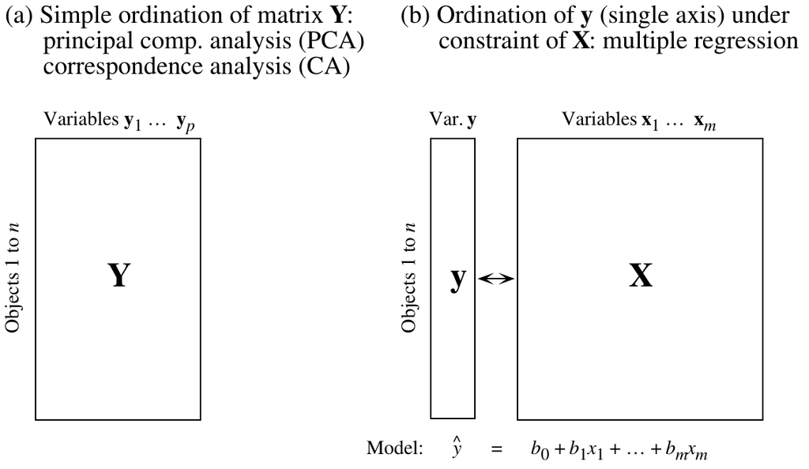

Рис. из Legendre, Legendre, 1998

## Прямая (ограниченная) ординация

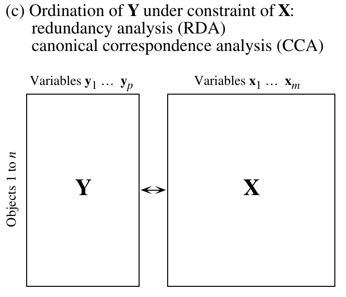

Рис. из Legendre, Legendre, 1998

## Если множественную линейную регрессию можно обобщить для нескольких зависимых переменных — получится RDA

\[\hat y _{i} = b _0 + b _1 x _{1i} + b _2 x _{2i} + ... + b _k + \epsilon _{i}\]

Уравнение множественной линейной регрессии можно переписать в виде матриц.

\[\left[\begin{array}{c} \hat y_1 \\ \hat y_2 \\ \vdots \\ \hat y_n \end{array}\right] = \left[\begin{array}{cc} 1 & x_{1,1} & x_{1,2} & \cdots & x_{1,k} \\ 1 & x_{2,1} & x_{2,2} & \cdots & x_{2,k} \\ \vdots & \vdots & \vdots & \ddots & \vdots \\ 1 & x_{n,1} & x_{n,2} & \cdots & x_{n,k} \end{array}\right] \cdot \left[\begin{array}{c} b _0 \\ b _1 \\ b _2 \\ \vdots \\ b _k \end{array}\right] + \left[\begin{array}{c} \epsilon _1 \\ \epsilon _2 \\ \vdots \\ \epsilon _n \end{array}\right] \]

Сокращенная форма записи: \(\mathbf{\hat y} = \mathbf{X} \mathbf{b} + \mathbf{\epsilon}\), причем \(\mathbf{b} = (\mathbf{X}^T\mathbf{X})^{-1}(\mathbf{X}^T \mathbf{y})\).

### Во множественной линейной регрессии \(\mathbf{\hat y} = \mathbf{X}(\mathbf{X}^T\mathbf{X})^{-1}(\mathbf{X}^T\mathbf{y})\)

### В RDA зависимая переменная — матрица, т.е. \(\mathbf{\hat Y} = \mathbf{X}(\mathbf{X}^T\mathbf{X})^{-1}(\mathbf{X}^T\mathbf{Y})\),

## Принцип RDA

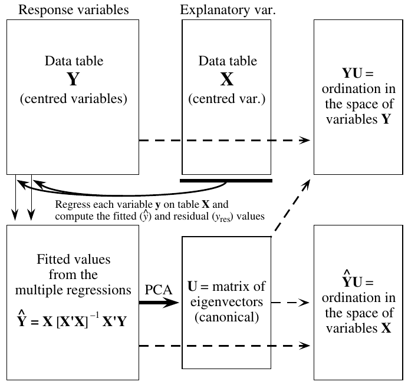

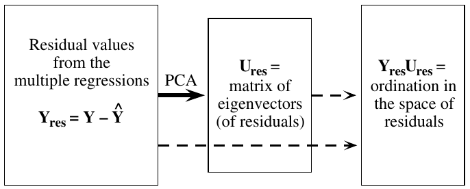

Рис. из Legendre, Legendre, 1998

## RDA в R

## RDA в vegan

- Зависимые переменные (отклики) - генетические данные
- Независимые переменные (предикторы) - переменные среды

```r
library(vegan)
bf_rda <- rda(gen ~ Altitude + Precipitation + Temp_Max + Temp_Min, data = env_geo)
summary(bf_rda)
```

```
##
## Call:
## rda(formula = gen ~ Altitude + Precipitation + Temp_Max + Temp_Min,      data = env_geo)
##
## Partitioning of variance:
##               Inertia Proportion
## Total             730      1.000
## Constrained       380      0.521
## Unconstrained     350      0.479
##
## Eigenvalues, and their contribution to the variance
##
## Importance of components:
##                         RDA1    RDA2    RDA3    RDA4     PC1     PC2
## Eigenvalue            357.20 19.6391 2.30457 0.75999 211.979 101.540
## Proportion Explained    0.49  0.0269 0.00316 0.00104   0.291   0.139
## Cumulative Proportion   0.49  0.5165 0.51966 0.52070   0.811   0.950
##                           PC3    PC4     PC5
## Eigenvalue            27.1344 7.9192 1.12065
## Proportion Explained   0.0372 0.0109 0.00154
## Cumulative Proportion  0.9876 0.9985 1.00000
##
## Accumulated constrained eigenvalues
## Importance of components:
##                         RDA1    RDA2    RDA3  RDA4
## Eigenvalue            357.20 19.6391 2.30457 0.760
## Proportion Explained    0.94  0.0517 0.00607 0.002
## Cumulative Proportion   0.94  0.9919 0.99800 1.000
##
## Scaling 2 for species and site scores
## * Species are scaled proportional to eigenvalues
## * Sites are unscaled: weighted dispersion equal on all dimensions
## * General scaling constant of scores:  10.2
##
##
## Species scores
##
##        RDA1    RDA2     RDA3    RDA4    PC1     PC2
## 0.4   0.637 -0.6604  0.19728 -0.2423  0.968 -0.4640
## 0.6   0.894 -0.7525 -0.00662  0.1207  2.244 -0.7172
```

[output cut: 40 more lines]

```
## PZ   1.7851  0.3046 -4.534 -1.551  1.2774  1.6760
## MC  -1.8164  7.1895 -2.071 -2.068  1.3839 -3.1474
## IF   0.0978  0.8467  0.470 -4.171  0.0249  1.1873
## AF   1.9613 -1.1890 -0.492 -5.267 -0.7763  3.2407
## GH  -4.5715 -1.5779 -4.080  1.225 -0.0225 -1.5923
## GL  -7.1804 -3.8767  1.268 -1.324  0.2697  1.3860
##
##
## Biplot scores for constraining variables
##
##                 RDA1   RDA2    RDA3   RDA4 PC1 PC2
## Altitude      -0.880 -0.361 -0.2287 -0.207   0   0
## Precipitation -0.827  0.532  0.0231 -0.177   0   0
## Temp_Max       0.863  0.311  0.1453 -0.371   0   0
## Temp_Min       0.914  0.213 -0.0672  0.339   0   0
```

## Структура общей изменчивости

О структуре изменчивости можно судить **по суммам собственных чисел ординационных осей** (ограниченных и неограниченных)

```
Partitioning of variance:
              Inertia Proportion
Total           729.6     1.0000
Constrained     379.9     0.5207
Unconstrained   349.7     0.4793
```

- Total - всех осей - общая изменчивость исходной матрицы откликов (генетич. структуры в разных сайтах)
- Constrained - осей, кот. являются комбинациями факторов среды - изменчивость объясненная средой
- Unconstrained - необъясненная изменчивость

## Важность различных компонент

Можно более подробно оценить, как распределяется изменчивость между осями

```
Eigenvalues, and their contribution to the variance

Importance of components:
                          RDA1     RDA2    RDA3    RDA4
Eigenvalue            357.2026 19.63905 2.30457 0.75999
Proportion Explained    0.4896  0.02692 0.00316 0.00104
Cumulative Proportion   0.4896  0.51650 0.51966 0.52070
                           PC1      PC2      PC3     PC4     PC5
Eigenvalue            211.9795 101.5400 27.13436 7.91921 1.12065
Proportion Explained    0.2905   0.1392  0.03719 0.01085 0.00154
Cumulative Proportion   0.8113   0.9504  0.98761 0.99846 1.00000
```

- Много изменчивости объяснено, но много осталось необъясненной. Первые две ограниченных оси объясняют 51% изменчивости, но первые две неограниченных объясняют еще 43%

## Распределение изменчивости, потенциально объяснимой факторами

```
Accumulated constrained eigenvalues
Importance of components:
                          RDA1     RDA2    RDA3  RDA4
Eigenvalue            357.2026 19.63905 2.30457 0.760
Proportion Explained    0.9402  0.05169 0.00607 0.002
Cumulative Proportion   0.9402  0.99193 0.99800 1.000
```

- Первая ограниченная ось объясняет большую часть потенциально объяснимой изменчивости. Остальные оси почти ничего не объясняют.

## Собственные векторы, нагрузки переменных = “species scores”

```r
scores(bf_rda, display = "species", choices = 1:5)
```

```
Species scores

        RDA1     RDA2      RDA3     RDA4     PC1     PC2
0.4   0.6371 -0.66036  0.197281 -0.24232  0.9681 -0.4640
0.6   0.8943 -0.75253 -0.006618  0.12069  2.2443 -0.7172
0.8   2.6182 -0.09492  0.141566  0.16990  2.7677  0.0607
1    -6.3502  0.12080  0.054622  0.04704 -3.3365 -2.4763
1.16  1.5535  1.33696  0.117722 -0.04195 -2.3548  2.5813
1.3   0.6470  0.05005 -0.504573 -0.05336 -0.2887  1.0155
```

## Корреляции между откликами и предикторами

- Сильная корреляция между генетической структурой и средой только для первой ограниченной оси. Для других - умеренные или слабые.

```r
spenvcor(bf_rda)
```

```
##  RDA1  RDA2  RDA3  RDA4
## 0.836 0.353 0.332 0.183
```

## Визуализация ординации

- Какие предикторы важнее всего?
- Какими факторами определяется значение зависимых переменных?

Триплоты:- переменные-отклики ("species"),- объекты ("sites")- переменные-предикторы (непрерывные в виде векторов, дискретные в виде центроидов)

Биплоты:- отклики + предикторы- объекты + предикторы

## Триплот корреляций (scaling = 2): Какие переменные среды важнее всего?

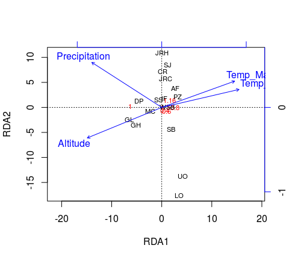

```r
plot(bf_rda, scaling = 2)
```

- Векторы - независимые переменные, факторы среды
- Надписи - объекты (сайты, особи, популяции и пр.)
- Красные надписи - зависимые переменные
- Косинусы углов между векторами - корреляции между соотв. переменными
- Расстояния не имеют смысла
- Проекция объекта на линию-вектор - значение переменной для данного объекта

## Пример интерпретации триплота корреляций

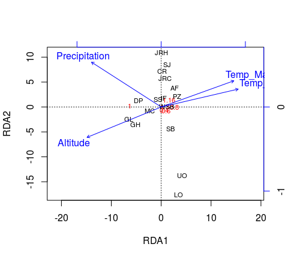

```r
plot(bf_rda, scaling = 2)
```

- Вдоль первой оси изменяется температура, высота и осадки
- Вдоль второй оси - немного меняется уровень осадков

## Триплот расстояний (scaling = 1)

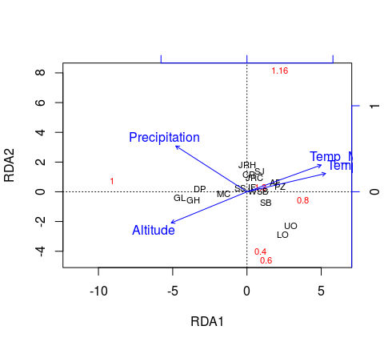

```r
plot(bf_rda, scaling = 1)
```

```r
# s.label(butterfly$xy, contour = butterfly$contour, inc = FALSE) # карта
```

- Надписи - объекты (сайты, особи, популяции и пр.)
- Красные надписи - зависимые переменные
- Векторы - независимые переменные, факторы среды
- Расстояния между точками - расстояния между наблюдениями
- Углы между векторами предикторов и откликов - корреляции между соотв. переменными, другие углы не имеют смысла
- Проекция объекта на линию-вектор отражает примерное положение данного объекта вдоль соотв. переменной (но не значение)
- Отношения между дискретными и непрерывными предикторами не интерпретируются

## Пример интерпреатции триплота расстояний

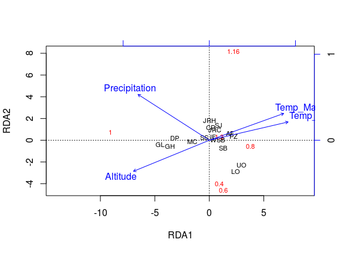

```r
plot(bf_rda, scaling = 1)
```

- Генетическая структура в LO и UO похожа, но не похожа на остальные места
- GL и GH - более высокогорные сайты, чем LO и UO

## Проверка значимости ординации

## Общий тест на значимость ординации

- тестируем гипотезу о том, что отношения между генотипом и средой значимы.

\(H _0\): значения предикторов в пробах не зависят от переменных среды (генетическая структура не зависит от среды)

- основан на пермутациях: проверяем, насколько наблюдаемая связь сильнее, чем если случайно переставить данные
- статистика - сумма всех соб. чисел ограниченных осей

## Общий тест: Влияют ли факторы на зависимые переменные?

### Есть ли связь генетики со средой?

```r
anova(bf_rda)
```

```
## Permutation test for rda under reduced model
## Permutation: free
## Number of permutations: 999
##
## Model: rda(formula = gen ~ Altitude + Precipitation + Temp_Max + Temp_Min, data = env_geo)
##          Df Variance    F Pr(>F)
## Model     4      380 2.99  0.023 *
## Residual 11      350
## ---
## Signif. codes:  0 '***' 0.001 '**' 0.01 '*' 0.05 '.' 0.1 ' ' 1
```

- связь генетической структуры и среды значима

## Тест факторов, type I эффекты: Какие факторы влияют на зависимые переменные?

```r
anova(bf_rda, by = "term")
```

```
## Permutation test for rda under reduced model
## Terms added sequentially (first to last)
## Permutation: free
## Number of permutations: 999
##
## Model: rda(formula = gen ~ Altitude + Precipitation + Temp_Max + Temp_Min, data = env_geo)
##               Df Variance    F Pr(>F)
## Altitude       1      279 8.79  0.004 **
## Precipitation  1       72 2.28  0.113
## Temp_Max       1       20 0.62  0.538
## Temp_Min       1        8 0.26  0.771
## Residual      11      350
## ---
## Signif. codes:  0 '***' 0.001 '**' 0.01 '*' 0.05 '.' 0.1 ' ' 1
```

## Тест факторов, type III эффекты: Какие факторы влияют на зависимые переменные?

```r
anova(bf_rda, by = "mar")
```

```
## Permutation test for rda under reduced model
## Marginal effects of terms
## Permutation: free
## Number of permutations: 999
##
## Model: rda(formula = gen ~ Altitude + Precipitation + Temp_Max + Temp_Min, data = env_geo)
##               Df Variance    F Pr(>F)
## Altitude       1        3 0.08   0.95
## Precipitation  1       34 1.08   0.33
## Temp_Max       1       25 0.79   0.46
## Temp_Min       1        8 0.26   0.80
## Residual      11      350
```

- Если протестировать каждый из факторов отдельно, при у словии, что все остальные включены в модель, то получится, что ни один из них не влияет.

## Тест значимости осей, ограниченных факторами:

- \(H _0\): значения переменных-откликов для объектов не зависят от переменных-предикторов
- пермутационный: выбирает оси, которые объясняют больше изменчивости, чем из др. матриц, полученных путем перестановок

## Тест значимости осей, ограниченных факторами: Вдоль какой из осей значимо меняется генетическая структура?

```r
anova(bf_rda, by = "axis")
```

```
## Permutation test for rda under reduced model
## Marginal tests for axes
## Permutation: free
## Number of permutations: 999
##
## Model: rda(formula = gen ~ Altitude + Precipitation + Temp_Max + Temp_Min, data = env_geo)
##          Df Variance     F Pr(>F)
## RDA1      1      357 11.24  0.003 **
## RDA2      1       20  0.62  0.558
## RDA3      1        2  0.07  0.979
## RDA4      1        1  0.02  0.997
## Residual 11      350
## ---
## Signif. codes:  0 '***' 0.001 '**' 0.01 '*' 0.05 '.' 0.1 ' ' 1
```

- Генетическая структура значимо меняется вдоль первой главной оси

## Выбор оптимальной модели

## Выбор оптимальной модели

У нас проблема. Если мы тестируем любой из факторов, после включения остальных в модель - он не влияет. Это значит, что модель не оптимальна.

Как подобрать оптимальную модель?

- Можно использовать пошаговый выбор модели: добавляем в модель лучшие переменные и снова исключаем те, что потеряли значимость. (Вспомните, как это было для регрессионных моделей.)

Какой можно использовать тест для сравнения моделей?

- Модели с разным числом предикторов можно сравнить при помощи пермутационного теста (AIC для ограниченных ординаций не существует!)
- **Осторожно!** В vegan факторы включенные в модель обозначаются "-", а факторы, исключенные из модели - "+"

## Пошаговый выбор оптимальной модели

Для пошагового выбора нам понадобятся полная и нулевая модели

```r
m1 <-rda(gen ~ Altitude + Precipitation + Temp_Max + Temp_Min, data = env_geo)
m0 <- rda(gen ~ 1, data = env_geo)
```

Запускаем пошаговый выбор

```r
m <- ordistep(m0, scope = formula(m1))
```

[output not shown]

## Оптимальная модель, отобранная при помощи пошагового алгоритма

```r
m$anova
```

```
##            Df AIC    F Pr(>F)
## + Altitude  1 101 8.69  0.005 **
## ---
## Signif. codes:  0 '***' 0.001 '**' 0.01 '*' 0.05 '.' 0.1 ' ' 1
```

## Частный анализ избыточности и компоненты объясненной инерции

## Зачем нужен частный анализ избыточности?

Мы уже обнаружили тесную связь генотипов со средой, и даже знаем, с какими переменными.

Но генотипы в близких местах могут быть похожи по разным причинам.

И теперь у нас два вопроса:

- Кто виноват?
- сходный климат в близких локациях
- поток генов между близкими колониями облегчен
- Что делать?
- Нужно удалить влияние географического положения, чтобы сделать корректный вывод о связи генотипов со средой.

## Частный анализ избыточности

- зависимость от одного набора переменных (предикторов), когда влияние другого (ковариат) исключено.

Техника:

1. Множественная регрессия зависимости предикторов от ковариат.
2. Остатки от этой регрессии — это то, что от ковариат не зависит — можно использовать в PCA в качестве предикторов (вместо исходных переменных среды).

Legendre & Legendre 1998

## Делаем частный RDA: зависимость генетической структуры от среды с учетом географического положения

```r
bf_prda_1 <- rda(gen ~ Altitude + Precipitation + Temp_Max + Temp_Min + Condition(x + y), data = env_geo)
anova(bf_prda_1) ## Пермутационный тест
```

```
## Permutation test for rda under reduced model
## Permutation: free
## Number of permutations: 999
##
## Model: rda(formula = gen ~ Altitude + Precipitation + Temp_Max + Temp_Min + Condition(x + y), data = env_geo)
##          Df Variance  F Pr(>F)
## Model     4      268  3  0.034 *
## Residual  9      201
## ---
## Signif. codes:  0 '***' 0.001 '**' 0.01 '*' 0.05 '.' 0.1 ' ' 1
```

- Климат объясняет генетическую изменчивость, даже после удаления влияния географических координат

## График ординации

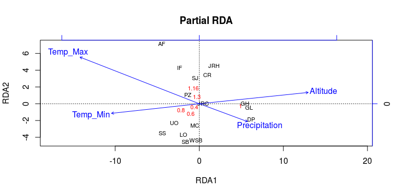

```r
plot(bf_prda_1, main = "Partial RDA")
```

- Смысл графика остался прежним, изменились нюансы
- Первая ось - высота и мин температура (кот. определяется высотой). Макс. температура с высокими нагрузками по обеим осям. Осадки почти ничего не объясняют.

## Задание

Проверьте значимость частного RDA, описывающего зависимость генетической структуры от среды с учетом географического положения

## Решение

```r
anova(bf_prda_1)
anova(bf_prda_1, by = "term")
anova(bf_prda_1, by = "mar")
anova(bf_prda_1, by = "axis")
```

## Решение: 1) Общий тест на значимость ординации

```r
anova(bf_prda_1)
```

```
## Permutation test for rda under reduced model
## Permutation: free
## Number of permutations: 999
##
## Model: rda(formula = gen ~ Altitude + Precipitation + Temp_Max + Temp_Min + Condition(x + y), data = env_geo)
##          Df Variance  F Pr(>F)
## Model     4      268  3  0.026 *
## Residual  9      201
## ---
## Signif. codes:  0 '***' 0.001 '**' 0.01 '*' 0.05 '.' 0.1 ' ' 1
```

- Связь генетической структуры и среды после удаления влияния географической близости попрежнему достоверна.

## Решение: 2) Тест на значимость осей (Type I)

```r
anova(bf_prda_1, by = "term")
```

```
## Permutation test for rda under reduced model
## Terms added sequentially (first to last)
## Permutation: free
## Number of permutations: 999
##
## Model: rda(formula = gen ~ Altitude + Precipitation + Temp_Max + Temp_Min + Condition(x + y), data = env_geo)
##               Df Variance    F Pr(>F)
## Altitude       1    212.9 9.51  0.002 **
## Precipitation  1      7.7 0.34  0.736
## Temp_Max       1     40.2 1.80  0.172
## Temp_Min       1      7.6 0.34  0.733
## Residual       9    201.4
## ---
## Signif. codes:  0 '***' 0.001 '**' 0.01 '*' 0.05 '.' 0.1 ' ' 1
```

- Высота определяет генетическую структуру популяций бабочек, если другие факторы не учитывать (если этот фактор входит в модель первым)

## Решение: 2) Тест на значимость осей (Type III)

```r
anova(bf_prda_1, by = "mar")
```

```
## Permutation test for rda under reduced model
## Marginal effects of terms
## Permutation: free
## Number of permutations: 999
##
## Model: rda(formula = gen ~ Altitude + Precipitation + Temp_Max + Temp_Min + Condition(x + y), data = env_geo)
##               Df Variance    F Pr(>F)
## Altitude       1     23.4 1.05   0.32
## Precipitation  1      7.6 0.34   0.72
## Temp_Max       1     40.8 1.82   0.17
## Temp_Min       1      7.6 0.34   0.72
## Residual       9    201.4
```

- Ни один из факторов не влияет на генетическую структуру, когда остальные входят в модель.
- Почему? Слабые эффекты?

## Решение: 3) Тест на значимость главных осей, ограниченных факторами

```r
anova(bf_prda_1, by = "axis")
```

```
## Permutation test for rda under reduced model
## Marginal tests for axes
## Permutation: free
## Number of permutations: 999
##
## Model: rda(formula = gen ~ Altitude + Precipitation + Temp_Max + Temp_Min + Condition(x + y), data = env_geo)
##          Df Variance    F Pr(>F)
## RDA1      1    216.2 9.66  0.018 *
## RDA2      1     44.4 1.98  0.390
## RDA3      1      7.3 0.33  0.885
## RDA4      1      0.6 0.03  1.000
## Residual  9    201.4
## ---
## Signif. codes:  0 '***' 0.001 '**' 0.01 '*' 0.05 '.' 0.1 ' ' 1
```

- Вдоль первой главной оси значимо меняется генетическая структура

## Компоненты объясненной изменчивости

## Компоненты изменчивости

К этому моменту мы знаем, что климат объясняет генетическую изменчивость, даже после удаления влияния географических координат. Хотя эффекты отдельных климатических переменных и не значимы.

Но какая часть изменчивости генетической структуры обясняется в чистом виде географической близостью, а какая — общим действием климата и географии?

## Общую изменчивость делим на части:

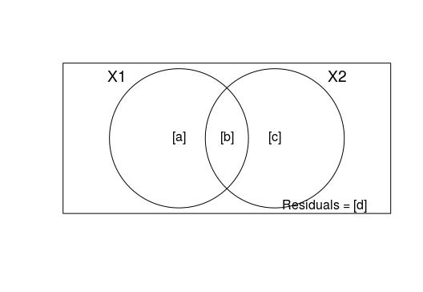

```r
showvarparts(2)
```

1. a + b + c - вся потенциально объяснимая средой и географией изменчивость
2. a - изменчивость, объясненная климатом
3. с - изменчивость, объясненная географией
4. b - изменчивость, совместно объясненная средой и географией

## Чтобы выделить компоненты изменчивости нам нужно несколько элементов

У нас уже есть **частный RDA №1: зависимость генетики от среды с учетом географии** (для a)

Нам нужен **частный RDA №2: генетика от географии с учетом свойств среды** (для c)

```r
bf_prda_2 <- rda(gen ~ x + y + Condition(Altitude + Precipitation + Temp_Max + Temp_Min), data = env_geo)
```

И **полная модель RDA генетика от среды и географического положения** (для a + b + c)

```r
bf_rda_full <- rda(gen ~ x + y + Altitude + Precipitation + Temp_Max + Temp_Min, data = env_geo)
```

## Задание: Найдите компоненты инерции

1. изменчивость, потенциально объяснимую средой и географией
2. изменчивость, связанную только со средой, но не с географией
3. изменчивость, связанную только с географией, но не со средой
4. изменчивость, объясненную одновременно средой и географией

### Подсказка

Смотрите на результаты разных RDA

## Решение: 1) Сколько изменчивости потенциально объясняется средой и географией?

```r
sum_full <- summary(bf_rda_full)
```

```
> sum_full

Partitioning of variance:
  Inertia Proportion
Total           729.6     1.0000
Constrained    =528.2=   0.7239
Unconstrained   201.4     0.2761
```

Изменчивость, объясненная вместе средой и географией, здесь достаточно велика

```r
(I_total <- sum_full$constr.chi)
```

```
## [1] 528
```

В отличие от нее, доля изменчивости, объясненной ограниченной матрицей, может быть довольно малой по оношении к общей изменчивости. Некоторые советуют сосредоточиться на доле от потенциально объяснимой изменчивости (от sum_full$constr.chi)

## Решение: 2) Изменчивость, объясненная климатом

```r
sum_prda_1 <- summary(bf_prda_1)
```

```
> sum_prda_1

Partitioning of variance:
  Inertia Proportion
Total           729.6     1.0000
Conditioned     259.7     0.3560
Constrained    =268.4=    0.3679
Unconstrained   201.4     0.2761
```

```r
(I_env <- sum_prda_1$constr.chi)
```

```
## [1] 268
```

## Решение 3) Изменчивость, объясненная географией

```r
sum_prda_2 <- summary(bf_prda_2)
```

```
> sum_prda_2

Partitioning of variance:
  Inertia Proportion
Total           729.6     1.0000
Conditioned     379.9     0.5207
Constrained    =148.3=    0.2032
Unconstrained   201.4     0.2761
```

```r
(I_geo <- sum_prda_2$constr.chi)
```

```
## [1] 148
```

## Решение: 4) Изменчивость, совместно объясненная средой и географией

```r
(I_env_geo <- I_total - I_env - I_geo)
```

```
## [1] 111
```

## Компоненты изменчивости - сводим результаты вместе

```r
comp <- data.frame(Inertia = c(I_env, I_geo, I_env_geo, I_total))
rownames(comp) <- c('Только среда', 'Только география', 'Среда и география вместе', 'Общая объяснимая инерция')
comp$Proportion <- comp$Inertia/sum(comp$Inertia[1:3]) * 100
colnames(comp) <- c('Инерция', '%')
comp
```

```
##                          Инерция     %
## Только среда                 268  50.8
## Только география             148  28.1
## Среда и география вместе     111  21.1
## Общая объяснимая инерция     528 100.0
```

## Take home messages

- Анализ избыточности помогает установить связь между несколькими наборами переменных. Один из наборов считается зависимым, другой считается объясняющим
- Для анализа необходимо, чтобы зависимости переменных-откликов от предикторов были линейными
- В ходе анализа выделяют два типа осей - ограниченные (объясненные) переменными-предикторами, и неограниченные (необъясненные) ими
- Частный анализ избыточности позволяет описать зависимость двух наборов переменных с поправкой на влияние дополнительных переменных (ковариат)
- При помощи частного анализа избыточности можно выделить компоненты изменчивости связанные с несколькими (2-4) наборами переменных-предикторов

## Дополнительные ресурсы

- Borcard, D., Gillet, F., Legendre, P., 2011. Numerical ecology with R. Springer.
- Legendre, P., Legendre, L., 2012. Numerical ecology. Elsevier.
- Oksanen, J., 2011. Multivariate analysis of ecological communities in R: vegan tutorial. R package version 2–0.
- The Ordination Web Page URL http://ordination.okstate.edu/ (accessed 10.21.13).
- Quinn, G.G.P., Keough, M.J., 2002. Experimental design and data analysis for biologists. Cambridge University Press.